# Probability Distributions

Nicholas J. Gotelli

February 18, 2020

### Probability distributions in R

#### Discrete distributions

- Poisson
  - Range: [0,$\infty$]
  - Parameters: size = number of trials, rate = $\lambda$
  - Interpretation: Distribution of events that occur during a fixed time interval or sampling effort with a constant rate of independent events
- Binomial
  - Range: [0, # of trials]
  - Parameters: size= number of trials; p = probability of positive outcome
  - Interpretation: Distribution of number of successful independent dichotomous trials, with constant p; resembles normal with large $\lambda$, or exponential with small $\lambda$
- Negative Binomial
  - Range: [0, $\infty$]
  - Parameters: size=number of successes; p = probability of success
  - Interpretation: Distribution of number of failures in a series of independent Bernouli trials, each with p = probability of a success. Generates a discrete distribution that is more heterogeneous (“overdispersed”) than Poisson

#### Continuous distributions

- Uniform
  - Range: [min,max]
  - Parameters: min = minimum boundary; max = maximum boundary
  - Interpretation: Distribution of a value that is equally likely within a specified range
- Normal
  - Range: [$-\infty,\infty$]
  - Parameters: mean = central tendency; SD = standard deviation
  - Interpretation: Symmetric bell-shaped curve with unbounded tails
- Gamma $\Gamma$
  - Range: [0,$\infty$]
  - Parameters: shape, scale
  - Interpretation: mean=$shape*scale$, variance=$shape*scale^2$; generates a variety of shapes (including normal and exponential) for positive continuous variables
- Beta $\beta$
  - Range: [0,1] (can be rescaled to any range by simple multiplication and addition)
  - Paramters: shape1, shape2
  - Interpretation: if shape1 and shape 2 are integers, interpret as a coin toss, with shape1 = # of successes + 1, shape2 = # of failures + 1. Gives distribution of value of p, estimated from data, which can range from exponential through uniform through normal (but all are bounded). Setting shape1 and shape2 <1 yields u-shaped distributions.

### The “grammar” of probability distributions in R

- `d` gives probability density function
- `p` gives cumulative distribution function
- `q` gives quantile function (the inverse of `p`)
- `r` gives random number generation

Combine these with the base name of the function. For example `rbinom` gives a set of random values drawn from a binomial, whereas `dnorm` gives the density function for a normal distribution. There are many probability distributions available in R, but we will discuss only 7 of them.

#### Poisson distribution

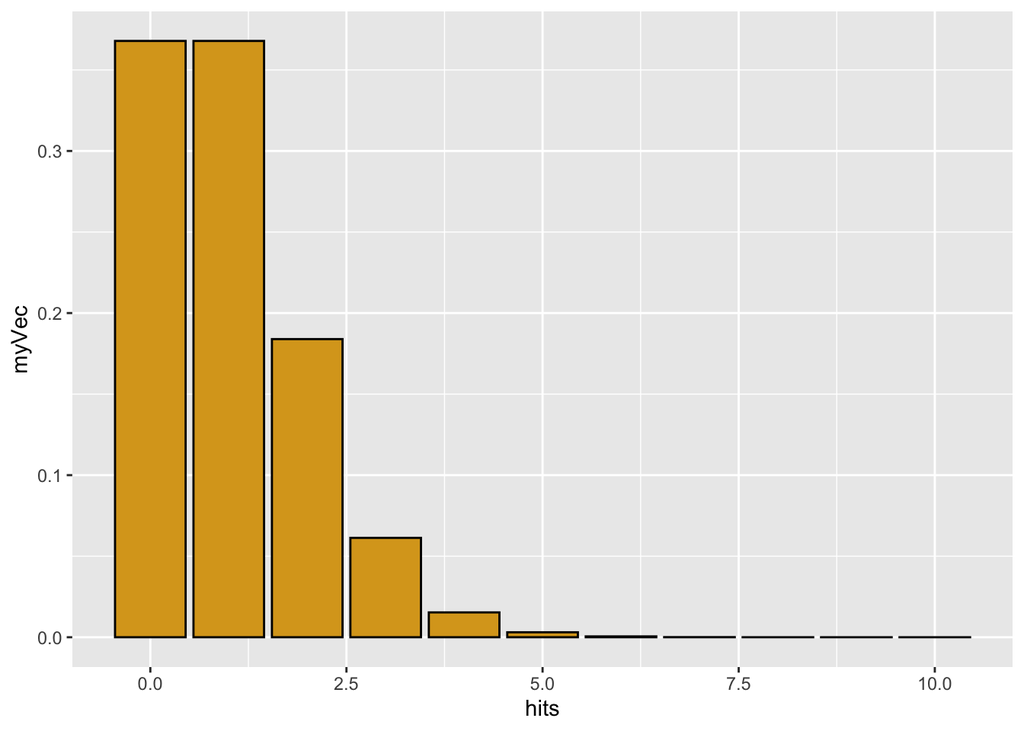

```r
library(ggplot2)
library(MASS)
#-------------------------------------------------
# Poisson distribution
# Discrete X >= 0
# Random events with a constant rate lambda
# (observations per time or per unit area)
# Parameter lambda > 0

# "d" function generates probability density
hits <- 0:10
myVec <- dpois(x=hits,lambda=1)
qplot(x=hits,y=myVec,geom="col",color=I("black"),fill=I("goldenrod"))
```

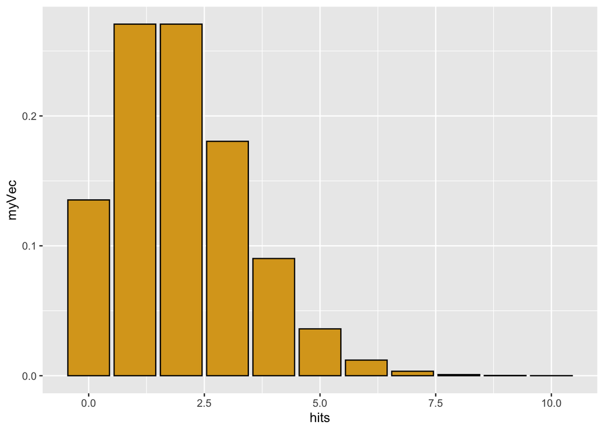

```r
myVec <- dpois(x=hits,lambda=2)
qplot(x=hits,y=myVec,geom="col",color=I("black"),fill=I("goldenrod"))
```

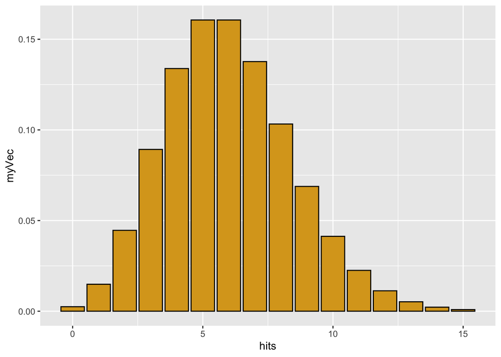

```r
hits <- 0:15
myVec <- dpois(x=hits,lambda=6)
qplot(x=hits,y=myVec,geom="col",color=I("black"),fill=I("goldenrod"))
```

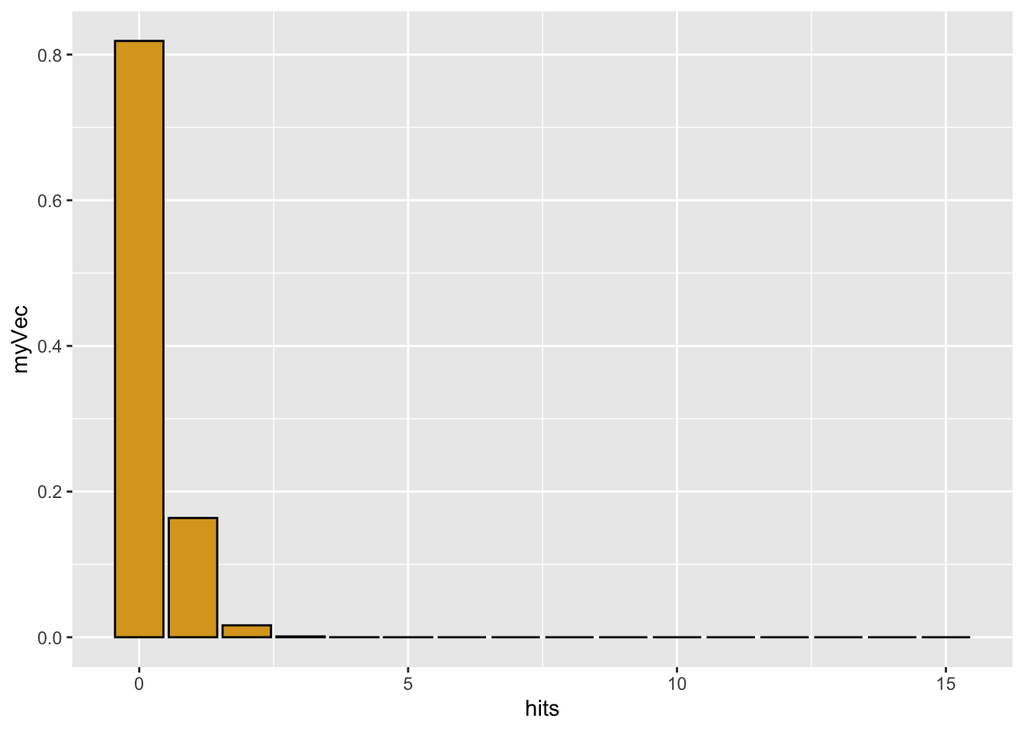

```r
hits <- 0:15
myVec <- dpois(x=hits,lambda=0.2)
qplot(x=hits,y=myVec,geom="col",color=I("black"),fill=I("goldenrod"))
```

```r
sum(myVec)  # sum of density function = 1.0 (total area under curve)
```

```
## [1] 1
```

```r
# for a Poisson distribution with lambda=2,
# what is the probability that a single draw will yield X=0?

dpois(x=0,lambda=2)
```

```
## [1] 0.1353353
```

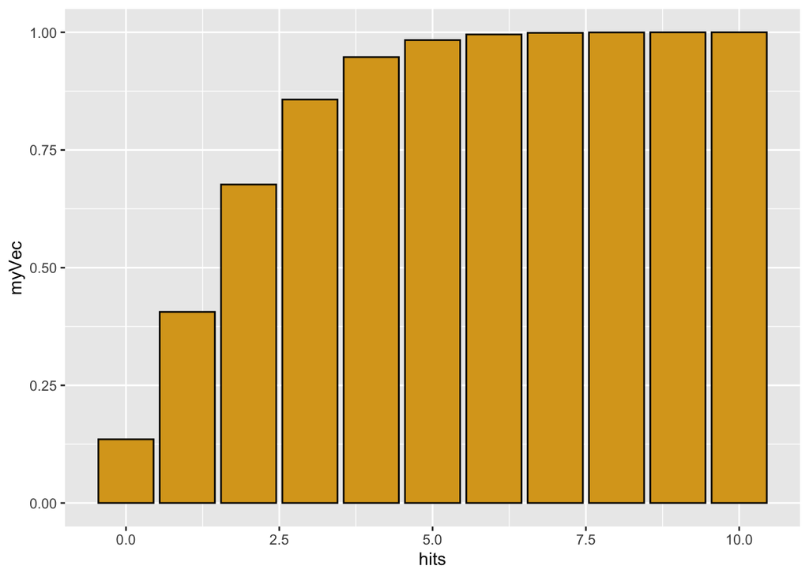

```r
# "p" function generates cumulative probability density; gives the
# "lower tail" cumulative area of the distribution

hits <- 0:10
myVec <- ppois(q=hits,lambda=2)
qplot(x=hits,y=myVec,geom="col",color=I("black"),fill=I("goldenrod"))
```

```r
# for a Poisson distribution with lambda=2,
# what is the probability that a single random draw will yield X <= 1?

ppois(q=1, lambda=2)
```

```
## [1] 0.4060058
```

```r
# We could also get this through dpois
p1 <- dpois(x=0,lambda=2)
p1
```

```
## [1] 0.1353353
```

```r
p2 <- dpois(x=1,lambda=2)
p2
```

```
## [1] 0.2706706
```

```r
p1 + p2
```

```
## [1] 0.4060058
```

```r
# The q function is the inverse of p
# What is the number of hits corresponding to 50% of the probability mass
qpois(p=0.5,lambda=2.5)
```

```
## [1] 2
```

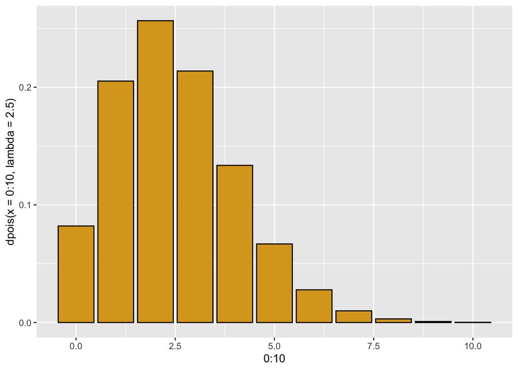

```r
qplot(x=0:10,y=dpois(x=0:10,lambda=2.5),geom="col",color=I("black"),fill=I("goldenrod"))
```

```r
# but distribution is discrete, so this is not exact
ppois(q=2,lambda=2.5)
```

```
## [1] 0.5438131
```

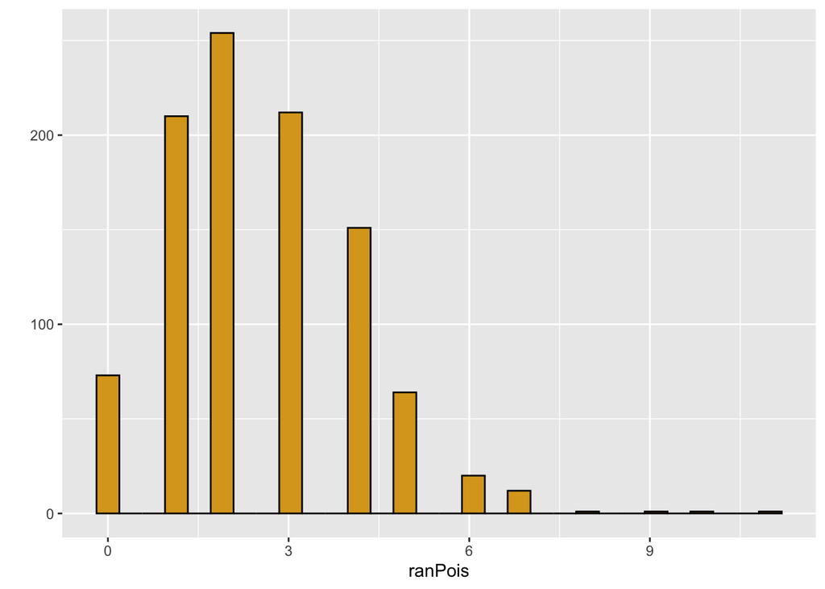

```r
# finally, we can simulate individual values from a poisson
ranPois <- rpois(n=1000,lambda=2.5)
qplot(x=ranPois,color=I("black"),fill=I("goldenrod"))
```

```r
# for real or simulated data, we can use the quantile
# function to find the empirical  95% confidence interval on the data

quantile(x=ranPois,probs=c(0.025,0.975))
```

```
##  2.5% 97.5%
##     0     6
```

#### Binomial distribution

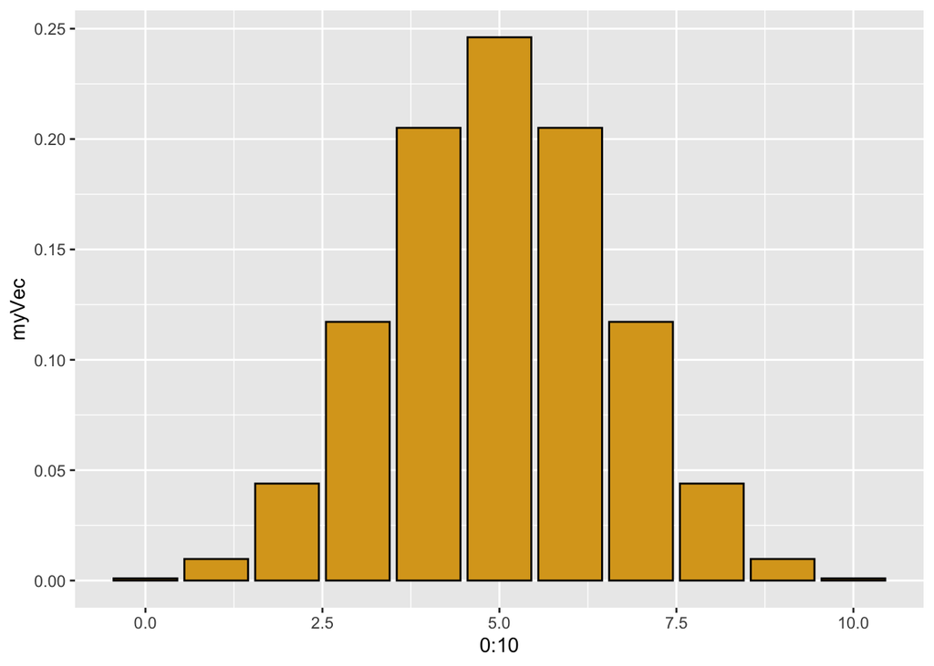

```r
#-------------------------------------------------
# Binomial distribution
# p = probability of a dichotomous outcome
# size = number of trials
# x = possible outcomes
# outcome x is bounded between 0 and number of trials

# use "d" binom for density function
hits <- 0:10
myVec <- dbinom(x=hits,size=10,prob=0.5)
qplot(x=0:10,y=myVec,geom="col",color=I("black"),fill=I("goldenrod"))
```

```r
# what is probability of getting 5 heads out of 10 tosses?
dbinom(x=5,size=10,prob=0.5)
```

```
## [1] 0.2460938
```

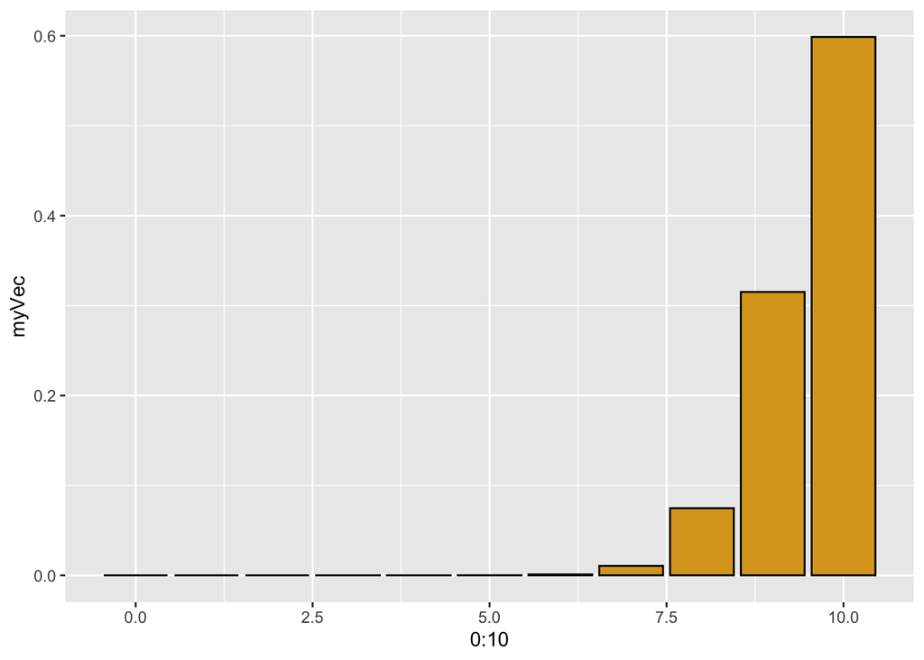

```r
# of course, the coin can be a biased one
myVec <- dbinom(x=hits,size=10,prob=0.95)
qplot(x=0:10,y=myVec,geom="col",color=I("black"),fill=I("goldenrod"))
```

```r
# use "p" binom for cumulative distribution


# what is the probability of getting 5
# or fewer heads out of 10 tosses?
pbinom(q=5,size=10,prob=0.5)
```

```
## [1] 0.6230469
```

```r
# symmetry requires odd number of tosses
pbinom(q=4,size=9,prob=0.5)
```

```
## [1] 0.5
```

```r
# what is a 95% confidence interval for 100 trials
# of a coin with p = 0.7 for heads?
qbinom(p=c(0.025,0.975),size=100,prob=0.7)
```

```
## [1] 61 79
```

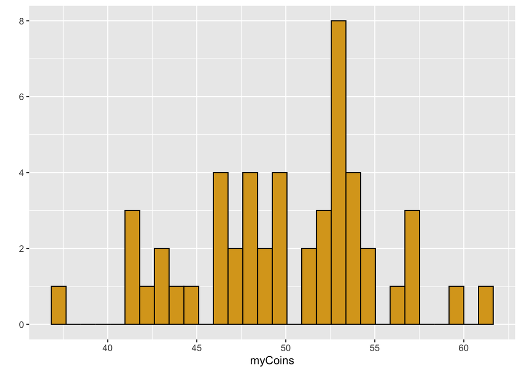

```r
# and how does this compare to the interval for an actual simlation of 50 tosses of 100 coins?

myCoins <- rbinom(n=50,size=100,prob=0.5)
qplot(x=myCoins,color=I("black"),fill=I("goldenrod"))
```

```r
quantile(x=myCoins,probs=c(0.025,0.975))
```

```
##   2.5%  97.5%
## 41.000 59.325
```

#### Negative Binomial distribution

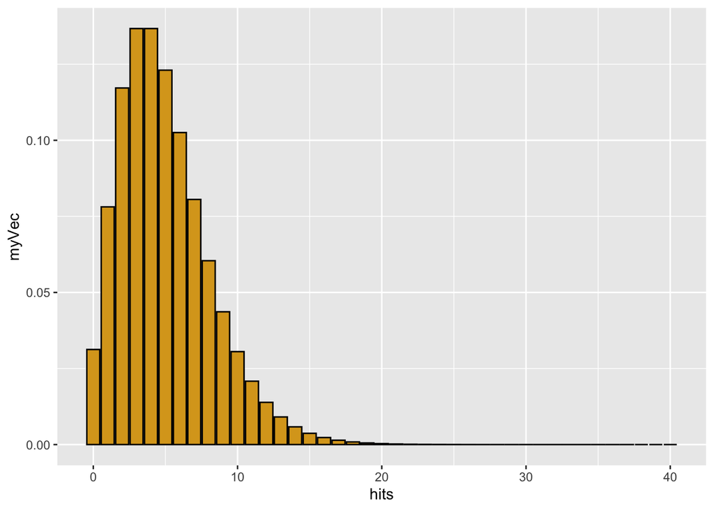

```r
#-------------------------------------------------
# negative binomial: number of failures (values of MyVec)
# in a series of (Bernouli) with p=probability of success
# before a target number of successes (= size)
# generates a discrete distribution that is more
# heterogeneous ("overdispersed") than Poisson
hits <- 0:40
myVec <- dnbinom(x=hits, size=5, prob=0.5)
qplot(x=hits,y=myVec,geom="col",color=I("black"),fill=I("goldenrod"))
```

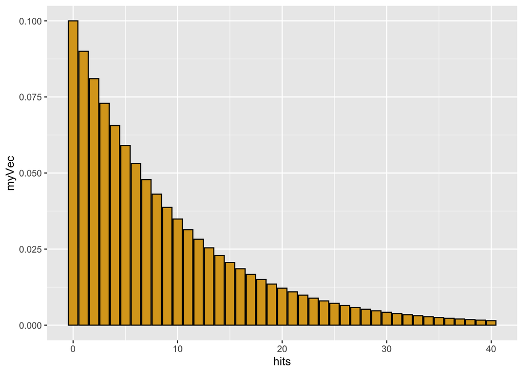

```r
# geometric series is a special case where N= 1 success
# each bar is a constant fraction 1 - "prob" of the bar before it
myVec <- dnbinom(x=hits, size=1, prob=0.1)
qplot(x=hits,y=myVec,geom="col",color=I("black"),fill=I("goldenrod"))
```

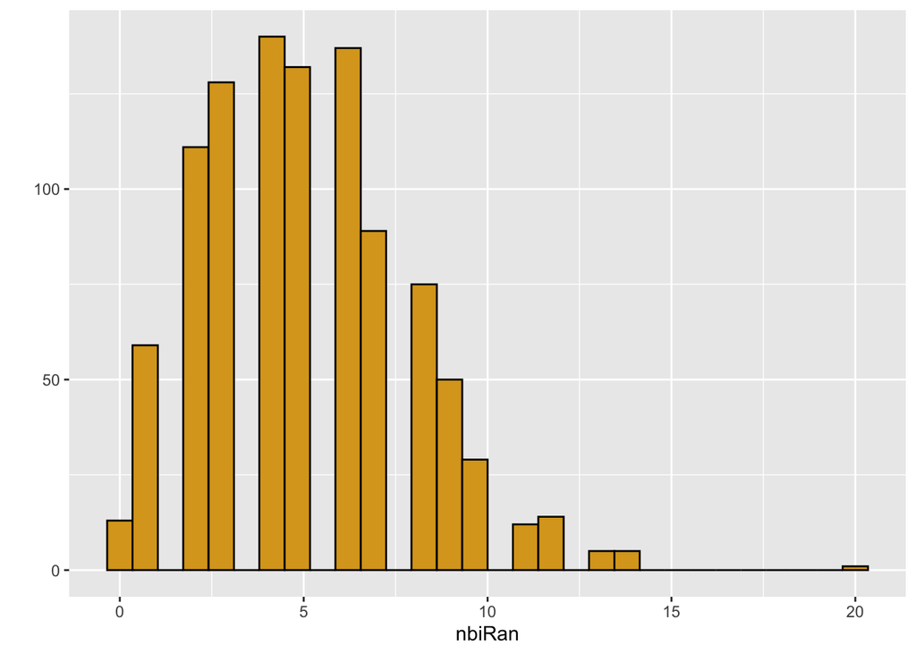

```r
# alternatively specify mean = mu of distribution and size,
# the dispersion parameter (small is more dispersed)
# this gives us a poisson with a lambda value that varies
# the dispersion parameter is the shape parameter in the gamma
# as it increases, the distribution has a smaller variance
# just simulate it directly

nbiRan <- rnbinom(n=1000,size=10,mu=5)
qplot(nbiRan,color=I("black"),fill=I("goldenrod"))
```

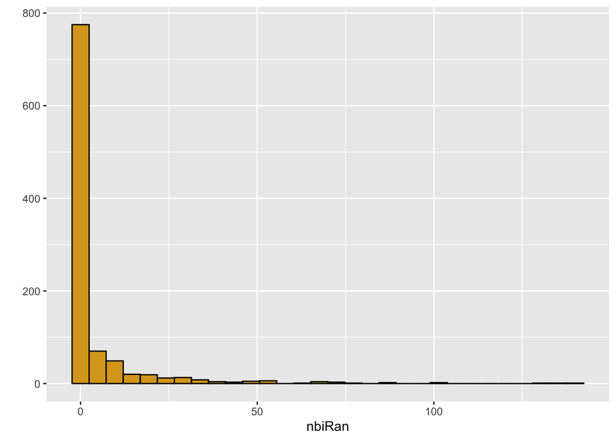

```r
nbiRan <- rnbinom(n=1000,size=0.1,mu=5)
qplot(nbiRan,color=I("black"),fill=I("goldenrod"))
```